# DA Privacy Task Sheet-- 2024

## Introduction

On the following pages is an exercise to give you a flavor of topics which will concern you as a Privacy Hub data analyst. Your answers will show us something of the way you work and think as well as how well you communicate. When in doubt about how to proceed, please use your best judgment. We do require that your answers are entirely your own work and that you cite where any external resources are used.

Your answers should include the code used to produce your findings. Where you describe your findings, do so in a non-technical way, being careful with wording. The reader should not need to execute your code to see your answers.

Good luck!

## Technical Instructions

The remainder of this notebook is divided into 2 sections. Section 1 consists of questions for you to answer directly in the notebook. Your submission should consist of an html or pdf export of this notebook. Send your results by attaching them in an email to the address that you received this exercise from.

Section 2 consists of an appendix that will be referenced in Section 1.

### Personal Hobbies

The following questions involve working with the dataset that was sent with this notebook. This is toy data which has been created within Privacy Hub and does not reflect any real people. The dataset includes a number of variables relating to physical attributes, hobbies and a ‘token’ which is used to distinguish one patient from another. A token is a value which is created from any one or more input values. It looks nonsensical (as it is a ‘hash’) and cannot be re-engineered to the original value. An example is provided alongside a more detailed explanation in the Appendix.

This data has been sent to you from a prospective client who intends to use the data for some analyses on inferring hobby trends across different demographics. The client has informed you that the tokens are created using data within the dataset itself, which is encrypted using a robust and trusted algorithm.

For the following questions, where appropriate, use code and language that is concise, efficient, easy-to-read and annotated to explain what’s going on. Where a question is open-ended, it is encouraged that you are succinct in your explanation.

### INITIAL OBSERVATIONS AND INFERENCES FROM THE DATASET

1. The dataset includes columns for various attributes such as token, name,surname, sex, age, height, weight.kg, eyecolour, test.group, hobbies, and marstat (marital status).
2. The dataset contains a mix of numerical (age, height, weight.kg, test.group) and categorical (sex, eyecolour, hobbies, marstat) data.
3. The variable 'test.group' is not clearly defined in the dataset. This lack of clarity might hinder precise analysis.
4. Misallignment in the data because of missing values.
5. The absence of standardization in the 'sex' and 'marstat' column.

a) Using the dataset and information above, determine which variables have been used to create the token. Can you comment on how this token might be improved?

Recommendations for Token Improvement:

b) Calculate the average weight for a person with blue eyes aged between 20 and 50 (inclusive). (Assume every row represents a unique individual).

```python
# Importing essential libraries
import pandas as pd

# Reading the dataset
data = 'DA_TaskSheet_Hobbies.txt'
dataframe = pd.read_csv(data)
```

```python
# Defining column names
column_names = ['token', 'name', 'surname', 'sex', 'age', 'height', 'weight.kg', 'eyecolour', 'test.group', 'hobbies', 'marstat']
```

```python
# Extracting the column headers
with open(data,'r')as file:
    first_line = file.readline().strip()

column_names= first_line.split()
df = pd.read_csv(data, delimiter='\s+')
```

```python
df
```

|  | token | name | surname | sex | age | height | weight.kg | eyecolour | test.group | hobbies | marstat |
| --- | --- | --- | --- | --- | --- | --- | --- | --- | --- | --- | --- |
| 0 | 29ef6f59fd9ac01e32b96a2deb31468cead3da1e55217b... | David | Stephens | male | 31.00 | 1.81 | 96.6 | blue | 1 | Plays cricket, football and rugby | married |
| 1 | b4b0039ae6874154757388eb58f07030f0f7d1c08df10d... | Karen | Bain | female | 23.00 | 152.00 | 45.4 | brown | 1 | Keen potter and home cook | single |
| 2 | 199083b48a273f2a7fb004f0223f865369737360a1b418... | Asaf | Fry | M | 28.00 | 1.79 | 74.4 | brown | 1 | Likes e-games | single |
| 3 | 063561ac27a4b06062fcdd489ce25eab82fd5bd80fe76f... | Jill | Bain | Female | 29.00 | 66.50 | 60.9 | brown | 1 | Has a horse and regularly rides | married |
| 4 | 7b665b53188c13e41731dd0e55799b6b8d999819999d10... | Fiona | Bain | Female | 19.00 | 1.46 | 79.2 | blue | 1 | Spends most free time with friends and family | divorced |
| 5 | 9404f142e65be3d93018e1ee87bf3e56dfdc21f9307501... | Natasha | Fry | F | 24.00 | 1.48 | 79.3 | brown | 2 | Prefers indoor pursuits like reading | married |
| 6 | 6e258a34e333bb551fb5b5d668954e0eb99772ac7ab784... | Jack | Rogers | Male | 62.00 | 1.76 | 81.7 | blue | 2 | Plays bowls twice a week | widowed |
| 7 | 948039ec6cce186762f21614f380485fc318b7d5639b4d... | Lee | Connor | M | 32.00 | 1.83 | 69.0 | blue | 2 | Likes backpacking, climbing and canoeing | Married |
| 8 | 57766529a3ec63fa4f6830857058f56df44eb1b4cad375... | Anastasia | Stuart | female | 18.00 | 1.53 | 79.2 | blue | 2 | Plays tennis for her county; Yorkshire | widowed |
| 9 | 18acf70a4501f571a896ecc42e0cd6978a4ac3f8b06281... | Kevin | Armstrong | male | 28.00 | 1.81 | 81.7 | blue | 2 | enjoys swimming and eating out with his wife | sing |
| 10 | a65d0b6a688ccd71c39fb5ea176f637f25fd0af79604e4... | Peter | Johnstone | 23 | 1.78 | 87.10 | brown | 3 | keen cricketer and tennis player | NaN | NaN |
| 11 | 145e5fcb7a7f2b439c42f4ad90ef29446b155ce62eb781... | Lillith | Bradley | Female | 58.00 | 61.80 | 51.0 | hazel | 3 | likes jigsaw puzzles and needlework | married |
| 12 | 947330250b7f20e77b61ef2b451ac9499a43d362df4beb... | Brian | Johnstone | Male | 46.00 | 1.90 | 81.9 | green | 3 | Says he has no time for hobbies | single |
| 13 | dd7b3e3ace9f14670dffe78df15f02c54ecc938d0d4e28... | Michelle | Bradley | F | 29.00 | 1.64 | 49.5 | green | 3 | Likes growing vegetables in her allotment | single |
| 14 | f8efc082434c43b0222b58a5b92e10454ea75395dc5994... | Zack | Andrews | M | 25.00 | 1.80 | 64.6 | brown | 3 | likes cooking and watching TV | NaN |
| 15 | 9c23594b8bc4a113acf801d518b7c2aee3024be9f0bbb4... | John | Jones | M | 19.00 | 1.93 | 60.3 | hazel | 4 | Plays the violin and is a member of a youth or... | married |
| 16 | bfff735ddf3ce73d4ca5251e752234ebd33378d2565741... | Caroline | Jones | F | 45.00 | 1.77 | 73.8 | blue | 4 | Likes walking her two dogs in the country | widowed |
| 17 | ede9e98407b47943eaccc3d3b42ae25b801e24b30bb8fc... | Susan | Frank | Female | 23.00 | 1.79 | 42.6 | blue | 4 | Swims for her region. Currently injured. | single |
| 18 | 9539097bc18e13efd9ce7153659ba9a6aeb2a5afd25e41... | Wendy | Brady | female | 20.00 | 145.00 | 57.7 | hazel | 4 | Likes going to the cinema with friends. | married |
| 19 | 66e988d2b0fc7bedc046823649957a5d017c79b6cece0d... | Michael | Ayre | male | 32.00 | 1.75 | 66.4 | hazel | 4 | Member of a cycling club. Also likes sailing. | divorced |
| 20 | 4b8817004e228fec88b0db83f3b264608a9a135bb6a2ad... | David | Jones | Male | 72.00 | 1.45 | 72.0 | brown | 5 | Enjoys reading fiction and non-fiction. | NaN |
| 21 | b4b0039ae6874154757388eb58f07030f0f7d1c08df10d... | Karen | Reid | Female | 23.00 | 64.30 | 60.1 | green | 5 | Often socialises with friends. | single |
| 22 | 6e258a34e333bb551fb5b5d668954e0eb99772ac7ab784... | Jack | Rogers | M | 62.00 | 150.00 | 76.1 | green | 5 | Enjoys country walks with his dog. | married |
| 23 | a6779cbb4419d1175da592a39eec49871ffa1fbf79ce28... | Kim | Connor | female | 39.00 | 64.00 | 77.0 | green | 3 | Plays in a brass band. | married |
| 24 | a6779cbb4419d1175da592a39eec49871ffa1fbf79ce28... | Kim | Brady | Male | 39.00 | 180.00 | 90.5 | green | 5 | Enjoys playing volleyball weekly. | single |

In the above data, it can be observed that the data is misalligned due to missing values which can impact an accurate data analysis.

```python
# Filtering for individuals with blue eyes and age between 20 and 50
filtered_data = df[(df['eyecolour'] == 'blue') & (df['age'] > 20) & (df['age'] < 50)]
filtered_data
```

|  | token | name | surname | sex | age | height | weight.kg | eyecolour | test.group | hobbies | marstat |
| --- | --- | --- | --- | --- | --- | --- | --- | --- | --- | --- | --- |
| 0 | 29ef6f59fd9ac01e32b96a2deb31468cead3da1e55217b... | David | Stephens | male | 31.0 | 1.81 | 96.6 | blue | 1 | Plays cricket, football and rugby | married |
| 7 | 948039ec6cce186762f21614f380485fc318b7d5639b4d... | Lee | Connor | M | 32.0 | 1.83 | 69.0 | blue | 2 | Likes backpacking, climbing and canoeing | Married |
| 9 | 18acf70a4501f571a896ecc42e0cd6978a4ac3f8b06281... | Kevin | Armstrong | male | 28.0 | 1.81 | 81.7 | blue | 2 | enjoys swimming and eating out with his wife | sing |
| 16 | bfff735ddf3ce73d4ca5251e752234ebd33378d2565741... | Caroline | Jones | F | 45.0 | 1.77 | 73.8 | blue | 4 | Likes walking her two dogs in the country | widowed |
| 17 | ede9e98407b47943eaccc3d3b42ae25b801e24b30bb8fc... | Susan | Frank | Female | 23.0 | 1.79 | 42.6 | blue | 4 | Swims for her region. Currently injured. | single |

```python
# Converting weight.kg to numeric format to calculate the mean
filtered_data.loc[:, 'weight.kg'] = pd.to_numeric(filtered_data['weight.kg'], errors='coerce')

averageWeight = filtered_data['weight.kg'].mean()
averageWeight
```

```
72.74000000000001
```

c) Comment on the distribution of values within the height column, can you explain why there may be such a wide range of values? (hint: it may be useful to research real height distributions in the human population).

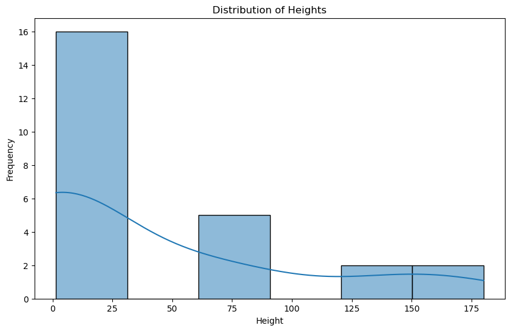

```
count     25.000000
mean      39.928000
std       58.906314
min        1.450000
25%        1.760000
50%        1.810000
75%       64.300000
max      180.000000
Name: height, dtype: float64
```

```python
# Plot for analysing the distribution of height
import matplotlib.pyplot as plt
import seaborn as sns

# Converting 'height' to numeric
df['height'] = pd.to_numeric(df['height'], errors='coerce')

# Plotting the distribution of height
plt.figure(figsize=(10, 6))
sns.histplot(df['height'].dropna(), kde=True)
plt.title('Distribution of Heights')
plt.xlabel('Height')
plt.ylabel('Frequency')
plt.show()

# Descriptive statistics for height
height_stats = df['height'].describe()

height_stats
```

Upon examining the descriptive statistics, it becomes evident that there are a total of 25 records in the dataset. The standard deviation is very large at 58.91 indicating large spread of values. The wide range of values for the height suggests that there could be a possibility of mix of units. Some heights are recorded in meters(For ex: 1.76) while others appears to be in centimeters(For ex: 180). This inconsistency leads to a skewed distribution in the above graph. The histogram represents the frequency of heights in various height ranges and the Kerel Density Estimate(KDE) describes a smoothed representation of the probability density function.

On referencing the research paper from the National Bureau of Economic Research which can be found at https://www.nber.org/system/files/working_papers/h0108/h0108.pdf, it was observed that there cannot be such huge variation in heights of human population. Typically, human heights follows a normal distribution with most values clustering around the mean and fewer at the extremes. The average adult human height usually ranges from about 1.5 to 1.95 meters. The presence of values far outside this range (like 1.45 or 180) indicates data entry errors or unit inconsistencies.

**Recommendation:**

1. Converting all heights to a consistent unit either meters or centimeters will correct the skewed distribution and make the data more interpretable.
2. Heights outside the typical human range should be flagged for review.This could be a potential data entry error. Once the data is cleaned and standardized, re-plotting the histogram will likely show a more typical bell-curve distribution which is an expected result for human heights.

d) Notice that row 12 (incl. header) begins to shift columns to the left and leads to misalignment. Further queries reveal that this is an error due to missing age information during manual data entry. Given the format of the file, can you identify a simple fix to ensure this misalignment doesn’t happen and formatting remains consistent?

The misalignment issue in record 11 was noticed when the file was exported in Excel for better understanding and to easily read and interpret the data. The misalignment primarily stemmed from missing age information in the dataset. This can be addressed by ensuring proper data entry and formatting in the source file. Given that the data is in text and space-separated format, an effective fix would be to introduce a placeholder for missing values

Inserting a consistent placeholder like 'NA' or a specific number like -1 in the position where data is missing will help solve this issue. For instance, if the age information is missing, the age column for that row should contain 'NA' or any chosen placeholder. This ensures that the columns remain aligned. However, NA seems to be a better option as it will be easily for the data analysis tools to represent and handle missing data. Another recommended fix is to implement checks at the data entry source to prevent missing values. For eaxmple, setting mandatory fields in a data entry form can ensure that all necessary information is provided.

e) The client wishes to use the dataset partly to analyze the relationship between sex and favorite hobby. Comment on any pre-processing steps you think are necessary before performing such analysis.

Before proceeding to analyze the relationship between sex and favorite hobby from the dataset, several standard pre-processing steps are necessary to ensure the accuracy and reliability of the analysis.

1. **Handling the missing values**  
   It is one of the common and basic tasks to be performed in any data analysis task. Missing values in both sex and hobbies column must be analyzed and checked for MCAR(Missing completely at random), MAR(Missing at random) or MNAR(Missing not a random). Then a specific method needs to be chosen to deal with these missing values. This can include imputation, deleting observations(rows) with missing values, replacing the value with reasonable alterntive or employ a missing data mechanism.
2. **Checking for data consistency**  
   The data in each of the columns have to be evaluated to ensure that the consistent and logical.
3. **Cleaning and Standardizing the 'sex' Column**  
   The values in the 'sex' column appears to be inconsistent (e.g., 'male', 'Male', 'M', 'female', 'Female', 'F'). These should be standardized to a consistent format. This can be achieved by converting the values to lowercase and tehn mapping it to a uniform format
4. **Processing the 'hobbies'column**  
   It can be seen that the hobbies column contain multiple hobbies in a single entry. Therefore, the hobbies in each entry can be parsed and then categorized into boarder groups(like sports, arts, ect) to perform a meaningful and accuarate analysis. This can be achieved by employing NLP techniques or text analysis to categorize teh hobbies based on the complexity and variety of hobbies.
5. **Performing Exploratory Data Analysis (EDA)**  
   EDA is a crucial step in understanding and preparing the dataset for future analysis. To understand the relationship between sex and hobbies, initially a basic frequency analysis can be carried out. We also need to understand the distribution of sexes in the dataset, understand the different broader categorization of hobbies and the frequency of hobbies in each of those categories, investigate if certain hobbies is prevalent in one sex over the other.

```python
# Standardize the 'sex' column to lowercase and then map to a uniform format
df['sex'] = df['sex'].str.lower().map({'male': 'male', 'm': 'male', 'female': 'female', 'f': 'female'})
```

f) Upon further conversation, the client reveals to you that the dataset provided is a sample of a larger dataset, which consists of 100,000 unique individuals.

```
i) Comment on the validity of using this data sample to draw any statistical conclusions about the entire dataset
ii) What advice would you give the client should they ask how best to prepare a data sample?
```

i)

The validity of using a sample to draw conclusions about a larger dataset depends on several factors:

**Sampling size and method:** The sample provided in the text file consists of 25 individuals, which is quite small compared to the total population of 100,000. However, a larger sample size increases the representativeness of the sample and can reduce the margin of error while drawing statistical conclusions. The sampling method used to select these 25 records is crucial. The sample should be randomly selected to ensure that every individual in the larger dataset had an equal chance of being included. This reduces selection bias and improves the representativeness of the sample.

**Diversity of the sample:** The sample should reflect the diversity of the entire dataset. This includes variables like age, sex, hobbies, and other features of the data. If the sample is not representative, then the conclusions drawn from it may not accurately reflect the entire population.

**Statistical significance and Confidence Intervals:** When drawing conclusions from a sample, it is important to calculate and report the statistical significance and confidence intervals. These metrics provide an understanding of the likelihood that the results from the sample accurately reflect the entire population.

ii)

Some key pieces of advice to prepare a data sample are listed below:

1. Use statistical methods to determine an appropriate sample size.
2. Random Sampling: Perform random sampling to ensure that the sample is randomly selected and that every individual in the larger dataset had an equal chance of being included, to avoid bias.
3. Stratified Sampling: Divide the population into strata(based on age groups, eyecolour, etc) and then randomly sampling from each stratum to ensure an effecive sampling that will generalize the entire data.
4. Data cleaning and pre-processing: Applying the same data cleaning and pre-processing steps used in the sample analysis to the entire dataset to check for consistency in how the data is treated is crucial for valid comparisons and analyses.
5. Keep detailed records of how the sample was selected and any pre-processing steps taken.

g) Part of our work at Privacy Hub invovles applying industry-standard guidance to various real life use cases. Such guidance often takes the form of modifications to a dataset in the name of reducing risk of re-identification. Briefly describe how you would implement the following modifications.

```
i) Height must be capped at 183cm for females and 198cm for males.
ii) All marital status values present must be limited to one of: "Married", "Single", "Divorced", "Widowed", or "Unknown". Furthermore, marital status must not be present for patients under 30.
```

i)

First, it has to be ensured that the 'height' column is in a numeric format and in the same unit as mentioned in the requirement i.e. in cm. This is important because the data might be in a text format and numeric operations like comparisons and assignments require the data to be in numeric data types. Conditional statements are used to check each record's sex and height. If a record is for a female and the height is greater than 183 cm, we set it to 183 cm. Similarly, if a record is for a male and the height is greater than 198 cm, we set it to 198 cm.

```python
#Saving a copy of the data
df1 = df

# Converting to numeric format to perform comparisons
df1['height'] = pd.to_numeric(df1['height'], errors='coerce')

# Applying height cap based on sex
df1.loc[(df1['sex'] == 'female') & (df1['height'] > 183), 'height'] = 183
df1.loc[(df1['sex'] == 'male') & (df1['height'] > 198), 'height'] = 198
```

ii)

This modification involves standardizing the marital status values and ensuring that marital status is not disclosed for individuals under 30. To achieve this, map all existing marital status values to one of the specified categories: "Married", "Single", "Divorced", "Widowed", or "Unknown". For individuals under 30, set the marital status to a placeholder or NaN.

It is observed that there is a record having maritial status as 'sing' which appears to be a typo or shorthand for 'single'. Considering this assumption to be true, the 'sing' value is mapped to 'Single', aligning with the standardized categories.

```python
marital_map = {
    'married': 'Married',
    'single': 'Single',
    'divorced': 'Divorced',
    'widowed': 'Widowed',
    'sing': 'Single'  # Mapping 'sing' to 'Single'
}

# Applying the updated mapping
df1['marstat'] = df1['marstat'].map(marital_map).fillna('Unknown')

# Removing marital status for individuals under 30
df1.loc[df1['age'] < 30, 'marstat'] = 'Unknown'
```

### Appendix

To illustrate the tokenisation process, consider the data found in the table below. To create the associated tokens, the variables var1 and var2 have been fed into a tokenization engine. Thus, rows with the same entries in both these variables have the same tokens, despite potentially representing different individuals (this is known as token colliding (or clashing)).

| var1 | var2 | token |
| --- | --- | --- |
| A | X | 2fw4hcl7 |
| A | Y | oa3t6saj |
| B | X | a56plm9 |
| A | X | 2fw4hcl7 |